# Analyzing and Predicting Human Trafficking Data

# Introduction

Human trafficking is a serious crime worldwide and affects thousands of people each year of all different ages and genders. With much of the human trafficking data being sensitive or missing, it can be difficult to find reliable and insightful analysis of the data. This tutorial walks through the data science pipeline by exploring the potential patterns and trends of the data concerning human trafficking victims, such as age, country and types of exploitation. This data is then used to attempt to predict missing data fields to project possible trends and classify human trafficking cases.

Tutorial By: Emily Son

# Libraries

A variety of libraries were used in creating dataframes, graphs, plots, and applying machine learning algorithms. The main libraries used throughout the tutorial are Pandas, Numpy, and Sklearn. The specific imports of the libraries are imported below:

```python
import pandas as pd
import numpy as np
import matplotlib.pyplot as plt
import seaborn as sns
from sklearn.experimental import enable_iterative_imputer
from sklearn.impute import IterativeImputer
import networkx as nx
from sklearn.model_selection import train_test_split
from sklearn import preprocessing
from sklearn.ensemble import RandomForestClassifier
from sklearn.experimental import enable_iterative_imputer
from sklearn.model_selection import cross_val_score
from sklearn.model_selection import RepeatedStratifiedKFold
from sklearn.pipeline import Pipeline
```

# Data Collection

## Data Source

The Counter-Trafficking Data Collaborative (CTDC) has compiled a dataset of data concerning almost 50k human trafficking victims. I found this dataset on Kaggle at https://www.kaggle.com/andrewmvd/global-human-trafficking. As much of the data regarding human trafficking victims is sensitive or missing, I had some difficulty finding a dataset that was publically available and comprehensive. This dataset contains many features of each victim's case (including 63 columns/features) and almost 50k victims. Therefore, I chose this dataset as there were many features to analyze and because it is publically available.

## Loading the Data

Because the dataset is already contained in a downloadable csv file, no curating or parsing of the data needs to be performed and it can be directly loaded into the tutorial using the pandas library.

The entire dataset, a csv file, is read into a pandas DataFrame and the missing values, denoted by -99, are replaced with NaN. The data is now in a DataFrame and can be easily viewed and manipulated throughout the tutorial.

```python
# The dataset csv file is read into a pandas dataframe
# Indicating low_memory to false to get rid of warning

trafficking_table = pd.read_csv('human_trafficking.csv', low_memory=False)
```

# Data Management/Representation

The missing values denoted by -99 are replaced with NaN in order to perform analysis on the data that take into account these missing values. Although not all 63 columns are explicitly used and represented in the tutorial, the more features will aid in the machine learning further into the tutorial. Therefore, they are not removed and the entire dataset is used as is to maximize the amount of data that is not missing.

```python
# Missing values are denoted as a string "-99" or the number -99 depending on the type of the column. Each version
# of missing value is replaced with NaN

trafficking_table.replace("-99", np.nan, inplace=True)
trafficking_table.replace(-99, np.nan, inplace=True)
```

```python
trafficking_table.head()
```

|  | yearOfRegistration | Datasource | gender | ageBroad | majorityStatus | majorityStatusAtExploit | majorityEntry | citizenship | meansOfControlDebtBondage | meansOfControlTakesEarnings | ... | typeOfSexPrivateSexualServices | typeOfSexConcatenated | isAbduction | RecruiterRelationship | CountryOfExploitation | recruiterRelationIntimatePartner | recruiterRelationFriend | recruiterRelationFamily | recruiterRelationOther | recruiterRelationUnknown |
| --- | --- | --- | --- | --- | --- | --- | --- | --- | --- | --- | --- | --- | --- | --- | --- | --- | --- | --- | --- | --- | --- |
| 0 | 2002 | Case Management | Female | 18--20 | Adult | NaN | NaN | CO | NaN | NaN | ... | NaN | NaN | NaN | NaN | NaN | 0.0 | 0.0 | 0.0 | 0.0 | 1.0 |
| 1 | 2002 | Case Management | Female | 18--20 | Adult | NaN | NaN | CO | NaN | NaN | ... | NaN | NaN | NaN | NaN | NaN | 0.0 | 0.0 | 0.0 | 0.0 | 1.0 |
| 2 | 2002 | Case Management | Female | 18--20 | Adult | NaN | NaN | CO | NaN | NaN | ... | NaN | NaN | NaN | NaN | NaN | 0.0 | 0.0 | 0.0 | 0.0 | 1.0 |
| 3 | 2002 | Case Management | Female | 18--20 | Adult | NaN | NaN | CO | NaN | NaN | ... | NaN | NaN | NaN | NaN | NaN | 0.0 | 0.0 | 0.0 | 0.0 | 1.0 |
| 4 | 2002 | Case Management | Female | 18--20 | Adult | NaN | NaN | CO | NaN | NaN | ... | NaN | NaN | NaN | NaN | NaN | 0.0 | 0.0 | 0.0 | 0.0 | 1.0 |

5 rows × 63 columns

The dataset consists of the following categories of features:

- Year
- Datasource of the victim's data
- Gender
- Age range
- Majority/Minority status (i.e. Adult or Minor)
- Citizenship
- Means of Control (i.e. debt, restrictions, threats, etc)
- Type of Exploit (i.e. labor, sex, marriage, etc)
- Type of Labor
- Type of Sex
- Recruiter Relationship (i.e. freind, relative, partner, other, unknown)
- Country of Exploitation

A deep copy of the dataset is made called 'data' to manipulate and use throughout the tutorial while always having the original data in 'trafficking_table'.

```python
# A deep copy is made with pandas copy function
data = pd.DataFrame.copy(trafficking_table, deep=True)
```

```python
data.head()
```

|  | yearOfRegistration | Datasource | gender | ageBroad | majorityStatus | majorityStatusAtExploit | majorityEntry | citizenship | meansOfControlDebtBondage | meansOfControlTakesEarnings | ... | typeOfSexPrivateSexualServices | typeOfSexConcatenated | isAbduction | RecruiterRelationship | CountryOfExploitation | recruiterRelationIntimatePartner | recruiterRelationFriend | recruiterRelationFamily | recruiterRelationOther | recruiterRelationUnknown |
| --- | --- | --- | --- | --- | --- | --- | --- | --- | --- | --- | --- | --- | --- | --- | --- | --- | --- | --- | --- | --- | --- |
| 0 | 2002 | Case Management | Female | 18--20 | Adult | NaN | NaN | CO | NaN | NaN | ... | NaN | NaN | NaN | NaN | NaN | 0.0 | 0.0 | 0.0 | 0.0 | 1.0 |
| 1 | 2002 | Case Management | Female | 18--20 | Adult | NaN | NaN | CO | NaN | NaN | ... | NaN | NaN | NaN | NaN | NaN | 0.0 | 0.0 | 0.0 | 0.0 | 1.0 |
| 2 | 2002 | Case Management | Female | 18--20 | Adult | NaN | NaN | CO | NaN | NaN | ... | NaN | NaN | NaN | NaN | NaN | 0.0 | 0.0 | 0.0 | 0.0 | 1.0 |
| 3 | 2002 | Case Management | Female | 18--20 | Adult | NaN | NaN | CO | NaN | NaN | ... | NaN | NaN | NaN | NaN | NaN | 0.0 | 0.0 | 0.0 | 0.0 | 1.0 |
| 4 | 2002 | Case Management | Female | 18--20 | Adult | NaN | NaN | CO | NaN | NaN | ... | NaN | NaN | NaN | NaN | NaN | 0.0 | 0.0 | 0.0 | 0.0 | 1.0 |

5 rows × 63 columns

# Exploratory Data Analysis (EDA)

The dataset contians a lot of information and I want to analyze the different possible patterns and trends present. I approach this analysis by first gaining a better understanding of the data by visualizing some of the main features/columns with graphs and plots. Then, these plots help identify possible trends and points of interest that we might want to analyze further and test using hypothesis testing and machine learning. This part of the data science pipeline allows us to explore the data and consider what we might want to test in the next step in the pipeline.

## Gender

Gender is the first feature that is visualized. Many people may think that only women are victims of human traffikcing. However, there are many types of human trafficking, not just sexual exploit, and men are not exempt from any of these categories. The distrubition of male and female victims, the two genders specified in the dataset, is visualized using a pie chart.

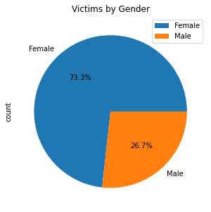

```python
# Creating a dataframe of the count of female and male, grouping by gender
gender_df = pd.DataFrame(data.groupby('gender').count()['ageBroad'])

# Renaming the column to represent the count
gender_df.rename(columns={'ageBroad': 'count'}, inplace=True)

# Displaying the pie chart of the percentage of female and male victims
gender_pie_chart = gender_df.plot.pie(y='count', figsize=(5, 5), title="Victims by Gender", autopct='%1.1f%%')
```

As suspected, 73.3% of the victims of human trafficking represented in this dataset are female. However, a considerable amount of victims are male, contrary to misconceptions that people may hold regarding human trafficking victims.

## Majority Status

Adult and children alike are victims of human trafficking. This pie chart seeks to visualize the majority status of the victims in this dataset, either as an adult or minor. A minor is any child under the age of 18.

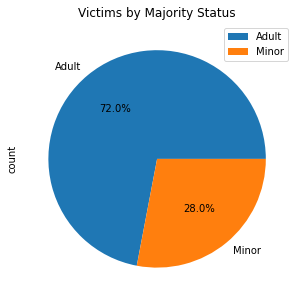

```python
# Creating a dataframe of the count of each status, 'Minor' and 'Adult'
status_df = pd.DataFrame(data.groupby('majorityStatus').count()['yearOfRegistration'])

# Renaming the column to represent the count
status_df.rename(columns={'yearOfRegistration': 'count'}, inplace=True)

# Displaying the percentage of adults and minors in a pie chart
status_pie_chart = status_df.plot.pie(y='count', figsize=(5, 5), title="Victims by Majority Status", autopct='%1.1f%%')
```

According to the pie chart, 72% of human trafficking victims are adults while 28% are children. However, I would suspect that the percentage of children is low because children do not usually have as much documentation and methods of identification as adults, such as driver's licenses and any sort of online footprint. Many cases are unreported and this dataset does not encapsulate every human trafficking victim.

## Types of Trafficking/Exploitation

Human trafficking involves different types of exploitation. The types observed in this dataset are:

1. Forced Labor
2. Sexual Exploit
3. Other Exploit
4. Sex and Labor
5. Forced Marriage
6. Forced Military
7. Organ Removal
8. Abduction
9. Slavery and Practices

These graphs aim to visualize the number of each type of trafficking and how it changes over time.

```python
# Creating a dataframe of the count of each type of trafficking/exploitation using pandas groupby and the count() method
# Each column for each type of exploit contains 0's and 1's. A 1 in any given row indicates that the victim was subjected
# to the exploit suggested by the column name.
# The total count of 1's and 0's for each column is added up and placed in the dataframe as the count.

exploit_df = pd.DataFrame(data.groupby('isForcedLabour').count()['yearOfRegistration'])
exploit_df.rename(columns={"yearOfRegistration": "forcedLabour"}, inplace=True)
exploit_df['sexualExploit'] = data.groupby('isSexualExploit').count()['yearOfRegistration']
exploit_df['otherExploit'] = data.groupby('isOtherExploit').count()['yearOfRegistration']
exploit_df['sexAndLabour'] = data.groupby('isSexAndLabour').count()['yearOfRegistration']
exploit_df['forcedMarriage'] = data.groupby('isForcedMarriage').count()['yearOfRegistration']
exploit_df['forcedMilitary'] = data.groupby('isForcedMilitary').count()['yearOfRegistration']
exploit_df['organRemoval'] = data.groupby('isOrganRemoval').count()['yearOfRegistration']
exploit_df['abduction'] = data.groupby('isAbduction').count()['yearOfRegistration']
exploit_df['slaveryPractices'] = data.groupby('isSlaveryAndPractices').count()['yearOfRegistration']
```

```python
# The dataframe displays the count of each exploit - how many individuals were victims of that exploit (1) and how many were not (0)
# NaN signifies that no individuals were victims of that type of exploit.
# Based on the observed data in this dataset, no victims were reported to be victims of forced military or organ removal.
exploit_df
```

| isForcedLabour | forcedLabour | sexualExploit | otherExploit | sexAndLabour | forcedMarriage | forcedMilitary | organRemoval | abduction | slaveryPractices |
| --- | --- | --- | --- | --- | --- | --- | --- | --- | --- |
| 0.0 | 16330 | 7794 | 23874 | 23378 | 10858 | 11450.0 | 11450.0 | 16332 | 1229 |
| 1.0 | 9772 | 16067 | 7064 | 78 | 168 | NaN | NaN | 39 | 359 |

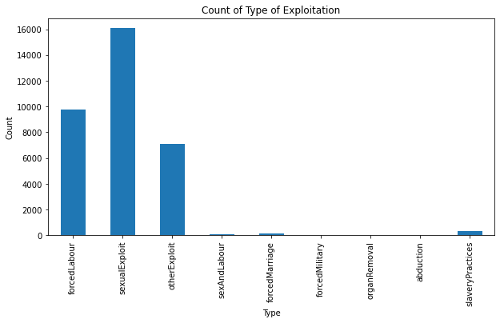

```python
# Bar graph for count of each type of exploitation in the dataset
exploit_df.iloc[1].plot.bar(figsize=(10, 5), title='Count of Type of Exploitation', xlabel='Type', ylabel='Count')
```

The bar graph shows the count of each type of exploitation. Sexual exploit occurs most frequently among the non-NaN data in the dataset with forced labor following as the second most frequent. Based on the data present in the dataset, there are no recorded victims who were forced to join the military or whose organs were removed. However, this data is not comprehensive and there are many missing fields and varying amounts of information for each year included. There could be more counts of each type of exploit than what is present in the data, which is something that will be attempted to predict later down the pipeline using machine learning algorithms.

### Types of Exploitation over time

Different methods of exploitation can rise and fall over time and patterns can exist between the counts of exploitation over time. The following analysis aims to observe the possible trends and see how the counts of exploitation and the different types change over time.

```python
# A dataframe of the counts of each type of exploit each year is created.
# The columns are first grouped by year and then each column is the aggregated sum of the count of that exploit for that year.
exploit_year_df = pd.DataFrame(data.groupby('yearOfRegistration').agg(forced_labour=("isForcedLabour", np.sum), sexual_exploit=("isSexualExploit", np.sum), \
                                                                     other_exploit=("isOtherExploit", np.sum), sex_labour=("isSexAndLabour", np.sum), \
                                                                     forced_marriage=("isForcedMarriage", np.sum), forced_military=("isForcedMilitary", np.sum), \
                                                                     organ_removal=("isOrganRemoval", np.sum), abduction=("isAbduction", np.sum), \
                                                                      slavery=("isSlaveryAndPractices", np.sum)))
```

```python
# The dataframe displays the counts of each exploit per year
exploit_year_df.head()
```

| yearOfRegistration | forced_labour | sexual_exploit | other_exploit | sex_labour | forced_marriage | forced_military | organ_removal | abduction | slavery |
| --- | --- | --- | --- | --- | --- | --- | --- | --- | --- |
| 2002 | 0.0 | 867.0 | 0.0 | 0.0 | 0.0 | 0.0 | 0.0 | 0.0 | 0.0 |
| 2003 | 0.0 | 357.0 | 0.0 | 0.0 | 0.0 | 0.0 | 0.0 | 0.0 | 0.0 |
| 2004 | 0.0 | 160.0 | 0.0 | 0.0 | 0.0 | 0.0 | 0.0 | 0.0 | 0.0 |
| 2005 | 817.0 | 492.0 | 11.0 | 0.0 | 0.0 | 0.0 | 0.0 | 0.0 | 0.0 |
| 2006 | 622.0 | 318.0 | 0.0 | 0.0 | 0.0 | 0.0 | 0.0 | 0.0 | 0.0 |

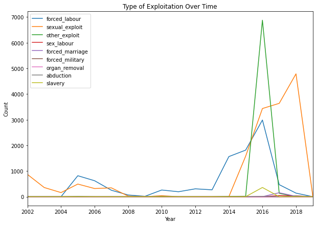

```python
# Line graph that represents each exploit over time and visualizes the 'exploit_year_df' dataframe
exploit_year_df.plot(figsize=(10, 7), xlabel='Year', ylabel='Count', xlim=(2002, 2019), title='Type of Exploitation Over Time')
```

Not as much data exists for 2019 as the other years, resulting in a sharp decrese for some of the types of exploitation and the reason they all have counts of 0 by 2019. Additionally, there are no recorded accounts of forced military and organ removal, as those two lines remain at 0 over time. A shar increase in other_exploit is seen around 2016 and the counts of forced labor and sexual exploitation start to increase around 2014.

### Count of Exploit vs Year for each type of exploit

In order to see the trend for each individual type of exploit more clearly, a separate scatter plot is created for each exploit over time.

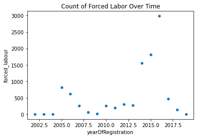

```python
# Resetting the index so year is a column in the dataframe
exploit_year_df.reset_index(inplace=True)

# Scatter plot of the counts of forced labor each year
exploit_year_df.plot.scatter(x='yearOfRegistration', y='forced_labour', title='Count of Forced Labor Over Time', xlabel='Year', ylabel='Count')
```

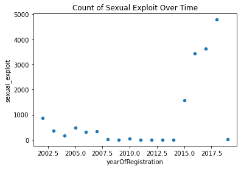

```python
# Scatter plot of the counts of sexual exploit each year
exploit_year_df.plot.scatter(x='yearOfRegistration', y='sexual_exploit', title='Count of Sexual Exploit Over Time', xlabel='Year', ylabel='Count')
```

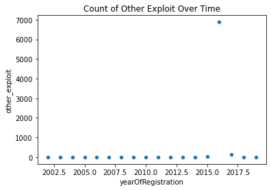

```python
# Scatter plot of the counts of other exploit each year
exploit_year_df.plot.scatter(x='yearOfRegistration', y='other_exploit', title='Count of Other Exploit Over Time', xlabel='Year', ylabel='Count')
```

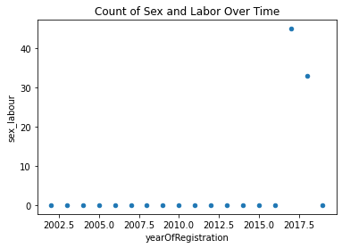

```python
# Scatter plot of the counts of sex labour over time
exploit_year_df.plot.scatter(x='yearOfRegistration', y='sex_labour', title='Count of Sex and Labor Over Time', xlabel='Year', ylabel='Count')
```

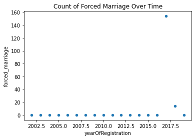

```python
# Scatter plot of counts of forced marriage over time
exploit_year_df.plot.scatter(x='yearOfRegistration', y='forced_marriage', title='Count of Forced Marriage Over Time', xlabel='Year', ylabel='Count')
```

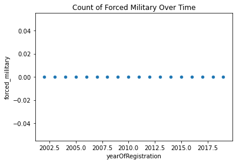

```python
# Scatter plot of counts of forced military over time
exploit_year_df.plot.scatter(x='yearOfRegistration', y='forced_military', title='Count of Forced Military Over Time', xlabel='Year', ylabel='Count')
```

There were no recorded counts of forced military over the years in the dataset.

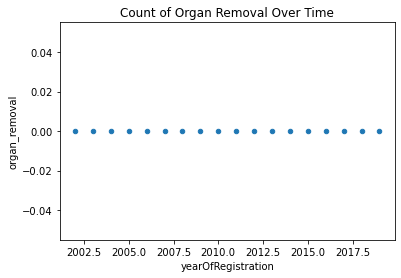

```python
# Scatter plot of counts of organ removal over time
exploit_year_df.plot.scatter(x='yearOfRegistration', y='organ_removal', title='Count of Organ Removal Over Time', xlabel='Year', ylabel='Count')
```

There were no recorded counts of organ removal over the years in the dataset.

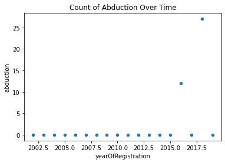

```python
# Scatter plot of counts of abduction over time
exploit_year_df.plot.scatter(x='yearOfRegistration', y='abduction', title='Count of Abduction Over Time', xlabel='Year', ylabel='Count')
```

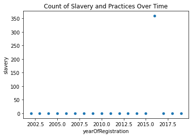

```python
# Scatter plot of counts of slavery and practices over time
exploit_year_df.plot.scatter(x='yearOfRegistration', y='slavery', title='Count of Slavery and Practices Over Time', xlabel='Year', ylabel='Count')
```

## Country

Country is another feature in the dataset, with a victim's citizenship and the country of exploitation recorded in the dataset. Victims might be transported and exploited in a country they are not originally from or exploited in their own country. By looking at the patterns between citizenship and country of exploitation, further analysis can be conducted on attempting to predict these relationships or track victims.

### Count by country

This analysis explores the differences in the number of human trafficking victims by country in which they were exploited in. These total counts are dispayed in a bar graph to visualize the differences between countries and to gain a greater perspective of the main places where many victims are exploited in.

```python
# Dataframe of the count of victims in each country
# The data is first grouped by the country they were exploited in and counted with count()
# Only one column of the resulting dataframe is needed to represent the count so the first one (yearOfRegistration) is used
country_df = pd.DataFrame(data.groupby("CountryOfExploitation").count()['yearOfRegistration'])

# The column is renamed to represent the count
country_df.rename(columns={'yearOfRegistration': 'count'}, inplace=True)
```

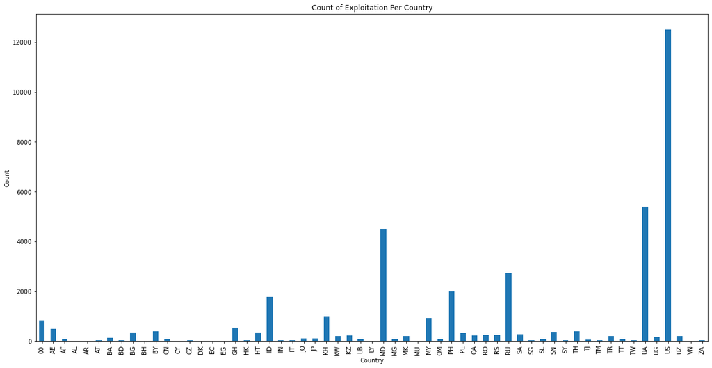

```python
# Bar graph of these counts
country_df.plot.bar(figsize=(20, 10), title='Count of Exploitation Per Country', xlabel='Country', ylabel='Count', legend=False)
```

The United States has the most amount of victims according to this dataset and far surpasses the other countries, coming to a total of over 12,000 victims. Following second is the Ukraine (UA) with 5,399 victims and then Moldova (MD) with 4,504 victims.

### Count by Country over time

While the total number of victims is represented in the bar graph above, observing how the amount of victims might change over time in each country can be insightful and provide further insight into the relationships in the data. The following line graph is generated similarly to how the bar graph was generated above, execpt now the data is grouped on the year and country of exploitation.

```python
# Dataframe of the count of victims in each country over time
# The data is first grouped by the year and country they were exploited in, and then counted with count()
# Only one column of the resulting dataframe is needed to represent the count so the first one (Datasource) is used
country_year_df = pd.DataFrame(data.groupby(['yearOfRegistration', 'CountryOfExploitation']).count()['Datasource'])

# The column is renamed to represent the count
country_year_df.rename(columns={'Datasource': 'count'}, inplace=True)
```

```python
# List of the name of all of the countries representd in the dataset
country_names = list(country_df.index.get_level_values(0))
```

```python
# Reset the index so that the year and country of exploitation are separate columns in the dataframe for plotting purposes
country_year_df.reset_index(inplace=True)
```

```python
country_year_df.head()
```

|  | yearOfRegistration | CountryOfExploitation | count |
| --- | --- | --- | --- |
| 0 | 2002 | BA | 41 |
| 1 | 2002 | MK | 175 |
| 2 | 2002 | RS | 248 |
| 3 | 2003 | BA | 86 |
| 4 | 2003 | MK | 19 |

```python
# Pivot the table so each country is its own column and each value in the table represents the count of victims per year
# This pivot is done for the purposes of plotting the count for each country over time as a line graph
country_year_df = country_year_df.pivot(index='yearOfRegistration', columns='CountryOfExploitation', values='count')
```

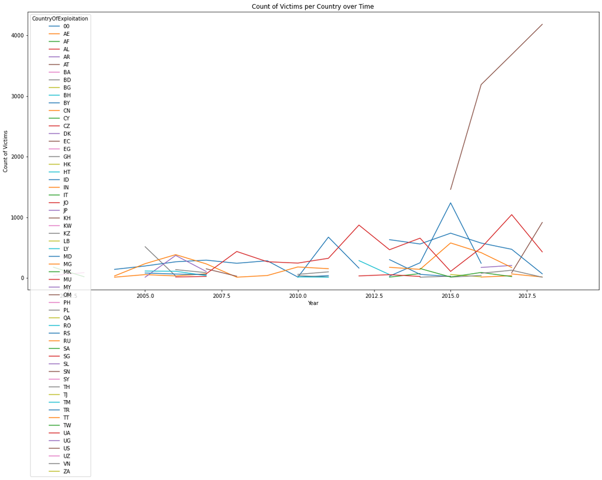

```python
# Graph of count of victims over time for each country
# Each country is its own line in the graph
country_year_df.plot(figsize=(20, 10), title='Count of Victims per Country over Time', xlabel='Year', ylabel='Count of Victims')
```

Similar to the bar graph, the line graph for the US (brown line) shows the high numer of victims who were exploited in the United States compared to all of the other countries. Many lines in the graph are in segements because the dataset does not include victims who were exploited in that country for those years or the data is missing (NaN). As a result, the lines in the graph are not continious due to the inconsistency in the data for each year. Despite the US, the other countries have a less dramatic change in the number of trafficked victims over time. Generally, the data suggests that the number of victims increase over time as the trend for most of the line graphs increases over time and with higher counts of victims occuring during later years, such as in 2015-2017.

## Age

Age is another feature that gives a greater picture of the distrubition of the types of individuals that are trafficked and the ages they can range from. This can also give more insight into the types of individuals who are forced into certain types of exploitation and if age has any relationship with the type of exploitation.

### Age Summary

The count of victims in each age range represented in the dataset is plotted in a bar graph and the percentage of each age range is visualized through a pie chart. The age ranges present in the dataset are:

- 0-8
- 9-17
- 18-20
- 21-23
- 24-26
- 27-29
- 30-28
- 39-47
- 48 and over

```python
# A dataframe of the count of victims in each age range is created by grouping the victims based on age and then counting
# Only one representation of the count is needed so the 'Datasource' column is used and then renamed to count
age_df = pd.DataFrame(data.groupby('ageBroad').count()['Datasource'])
age_df.rename(columns={'Datasource': 'count'}, inplace=True)
```

```python
# Reordering the age ranges in increasing order in the dataframe
ages = ['0--8', '9--17', '18--20', '21--23', '24--26', '27--29', '30--38', '39--47', '48+']
age_df = age_df.reindex(ages)
```

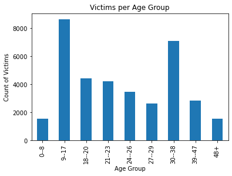

```python
# Bar graph for the number of victims per age group
age_df.plot.bar(title='Victims per Age Group', xlabel='Age Group', ylabel='Count of Victims', legend=False)
```

According to the bar graph, over 8,000 of the victims are between the ages of 9-17. This is the highest number of victims for any one age group. However, majority of the victims, as seen before, are adults as they range from the ages of 18 to 48 and over. But it is still alarming how many victims are minors and specifically pre-teens/teenagers if they are between the ages of 9-17.

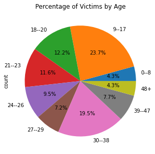

```python
# Pie chart of percentage of victims per age group
age_df.plot.pie(y='count', figsize=(5, 5), title="Percentage of Victims by Age", autopct='%1.1f%%', legend=False)
```

This pie chart displays the same information as above, just in a different way. In the pie chart, we can see that 23.7% of victims are between the ages of 9-17 and 19.5% are between 30-38 years old.

### Age over time

In addition to just looking at age, we can see the age over time and if there is great differences or patterns in the victims' ages as time goes on. The ages are plotted as individual lines in the graph.

```python
# A dataframe for the number of victims by age over time is created by grouping the victims by the year
# and their age range and then counting how many fall in each category
age_year_df = pd.DataFrame(data.groupby(['yearOfRegistration', 'ageBroad']).count()['Datasource'])
# The column is renamed to represent the count
age_year_df.rename(columns={'Datasource': 'count'}, inplace=True)
# The index is reset to include the year and age range as separate columns in the dataframe for plotting purposes
age_year_df.reset_index(inplace=True)
```

```python
# Pivot the dataframe so that each age range is its own column and the values in the table represent the number of victims for each year
age_year_df = age_year_df.pivot(index='yearOfRegistration', columns='ageBroad', values='count')
```

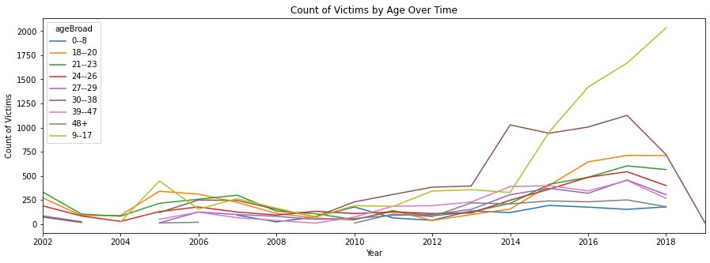

```python
# Line graph of number of victims in each age range over time
age_year_df.plot(xlim=(2002, 2019), figsize=(15, 5), title='Count of Victims by Age Over Time', xlabel='Year', ylabel='Count of Victims')
```

The line graph shows the number of victims per age range remaining relatively the same until around 2013 in which the number of victims starts to increase for each age range. The age ranges of 9-17 and 30-38 see the most dramatic increase in number of victims starting 2014 and 2013, respectively. However, the line graph for ages 9-17 continues to increase at a fast rate from 2014 to 2018, starting at less than 500 in 2014 and then reaching about 2,000 victims in 2018.

### Age and type of labor

Age can also be associated to the type of exploitation victims experience. The following analysis groups each age group and totals the number of victims for each type of exploitation, then plotting those totals in a line graph.

```python
# A dataframe for the number of victims by age for each type of exploitation is created by grouping the victims
# by the year and the exploitation and then counting how many fall in each category.

# Forced Labor count by age
age_exploit_df = pd.DataFrame(data.groupby(['ageBroad', 'isForcedLabour']).count()['yearOfRegistration'])
age_exploit_df.rename(columns={"yearOfRegistration": "forcedLabourCount"}, inplace=True)

# Sexual exploit count by age
age_exploit_df['sexualExploitCount'] = data.groupby(['ageBroad', 'isSexualExploit']).count()['yearOfRegistration']

# Other exploit count by age
age_exploit_df['otherExploitCount'] = data.groupby(['ageBroad', 'isOtherExploit']).count()['yearOfRegistration']

# Sex and labor count by age
age_exploit_df['sexLaborCount'] = data.groupby(['ageBroad', 'isSexAndLabour']).count()['yearOfRegistration']

# Forced marriage by age
age_exploit_df['forcedMarriageCount'] = data.groupby(['ageBroad', 'isForcedMarriage']).count()['yearOfRegistration']

# Forced military by age
age_exploit_df['forcedMilitaryCount'] = data.groupby(['ageBroad', 'isForcedMilitary']).count()['yearOfRegistration']

# Organ removal by age
age_exploit_df['organRemovalCount'] = data.groupby(['ageBroad', 'isOrganRemoval']).count()['yearOfRegistration']

# Slavery count by age
age_exploit_df['slaveryCount'] = data.groupby(['ageBroad', 'isSlaveryAndPractices']).count()['yearOfRegistration']

# Resetting index so age range is a separate column in the dataframe
age_exploit_df.reset_index(inplace=True)

# Removing the counts of victims that did not undergo the exploitation. This is denoted by rows that represent the
# number of 0's in each exploitation category. In this case, it is all the even numbered rows that need to be dropped.
age_exploit_df.drop([0, 2, 4, 6, 8, 10, 12, 14, 16], inplace=True)

age_exploit_df
```

|  | ageBroad | isForcedLabour | forcedLabourCount | sexualExploitCount | otherExploitCount | sexLaborCount | forcedMarriageCount | forcedMilitaryCount | organRemovalCount | slaveryCount |
| --- | --- | --- | --- | --- | --- | --- | --- | --- | --- | --- |
| 1 | 0--8 | 1.0 | 222 | 158 | 30.0 | NaN | NaN | NaN | NaN | NaN |
| 3 | 18--20 | 1.0 | 346 | 2936 | NaN | 14.0 | 15.0 | NaN | NaN | NaN |
| 5 | 21--23 | 1.0 | 475 | 2350 | 16.0 | NaN | 27.0 | NaN | NaN | NaN |
| 7 | 24--26 | 1.0 | 521 | 1568 | NaN | NaN | 15.0 | NaN | NaN | NaN |
| 9 | 27--29 | 1.0 | 643 | 891 | NaN | NaN | 11.0 | NaN | NaN | NaN |
| 11 | 30--38 | 1.0 | 2542 | 1605 | 29.0 | 32.0 | NaN | NaN | NaN | NaN |
| 13 | 39--47 | 1.0 | 1086 | 388 | 30.0 | NaN | NaN | NaN | NaN | NaN |
| 15 | 48+ | 1.0 | 386 | 167 | NaN | NaN | NaN | NaN | NaN | NaN |
| 17 | 9--17 | 1.0 | 1115 | 5077 | 52.0 | 32.0 | 11.0 | NaN | NaN | NaN |

The age of some victims are missing in the dataset. As a result, some of the counts of victims for each exploitation type by age group are NaN even if victims who were exploited that way exist. For example, victims were forced into slavery and other practices, but all of the values for that column are NaN because all of the ages for those victims are missing.

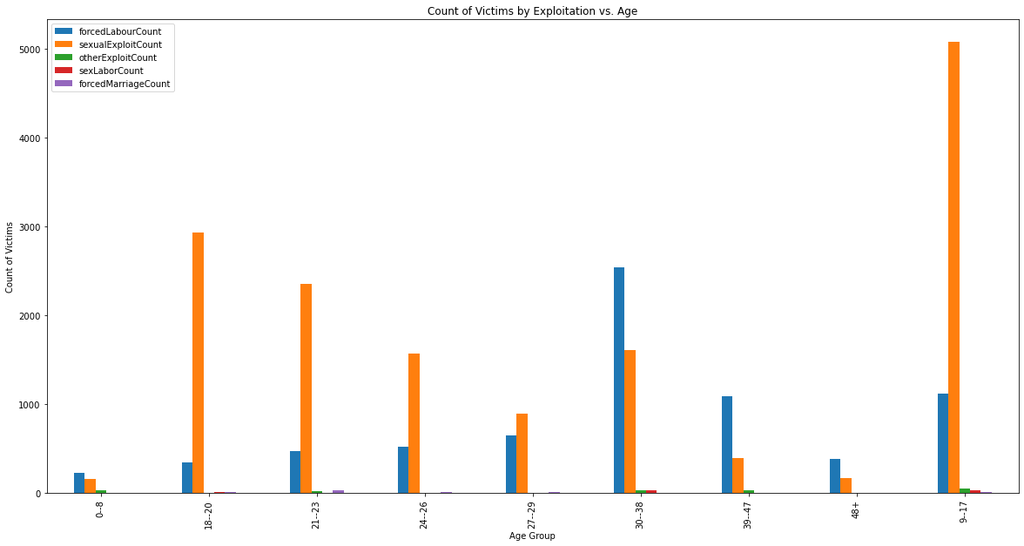

```python
# Bar graph of the counts of each type of exploit by age
age_exploit_df.plot.bar(x='ageBroad', y=['forcedLabourCount', 'sexualExploitCount', 'otherExploitCount', 'sexLaborCount', 'forcedMarriageCount'], \
                       title='Count of Victims by Exploitation vs. Age', xlabel='Age Group', ylabel='Count of Victims', figsize=(20, 10))
```

Looking at each type of labor by age group, the main way children from the ages of 9-17 are exploited is through sexual exploit. The same applies to those between ages of 18-29. However, those from 30 and up and also from 0-8 years old are exploited the most through forced labor. It seems that children and younger adults in their 20's are exploited sexually more frequently and those in their 30's and beyond are exploited through a means of labor.

# Citizenship

The last feature we will analyze before moving onto the next phase of the data science pipeline is the citizenship of the victims. The citizenship can show the distribution of victims based on their home country and as a result, which residents of countries might be more vulnerable to trafficking. When citizenship is analyzed with country of exploitation, we can see the possible trends between where victims are from and where they tend to end up.

### Citizenship summary

This summary visualizes the count of victims based on their citizenship as noted in the dataset.

```python
# A dataframe of the count of victims grouped by their citizenship is created
citizen_df = pd.DataFrame(data.groupby("citizenship").count()['yearOfRegistration'])
```

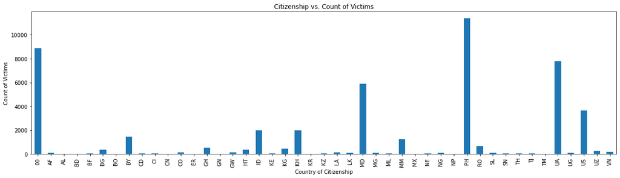

```python
# Bar graph of the count of victims for each country of citizenship
citizen_df.plot.bar(figsize=(20, 5), title='Citizenship vs. Count of Victims', xlabel='Country of Citizenship', ylabel='Count of Victims', legend=False)
```

This graph shows that most of the vitims are from or are citizens of PH, the Philippines. This is contrary to the country where victims are exploited the most, the United States, suggesting that the country of origin is not always the country of exploitation for trafficking victims.

### Citizenship and Country of Exploitation pairs

Patterns can also exist among victim's country of origin and the country of exploitation, suggesting patterns of transportation that victims undergo. Often times victims in one country can be falsely promised a job and new life in a different country and end up agreeing on the premise of false promises. These victims often end up receiving little to no wage and are threatened by their exploiters.

```python
# A dataframe that groups victims by their citizenship and country of exploitation and totals the number of victims with the same pairing by a count
citizen_country_df = pd.DataFrame(data.groupby(['citizenship', 'CountryOfExploitation']).count()['Datasource'])

# Renaming the column to represent the count
citizen_country_df.rename(columns={'Datasource': 'count'}, inplace=True)
```

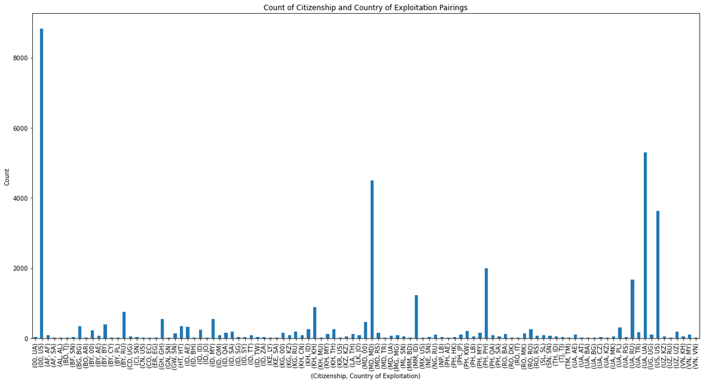

```python
# Bar graph of the count of each pairing of countries
citizen_country_df.plot.bar(figsize=(20, 10), title='Count of Citizenship and Country of Exploitation Pairings', \
                            xlabel='(Citizenship, Country of Exploitation)', ylabel='Count', legend=False)
```

The most frequent pairing is (00, US). A country code of 00 indicates that the country of citizenship is unknown and US represents the country of exploitation. This makes sense as we saw earlier that the US held the highest number of victims based on country of exploitation. The second highest pairing is (UA, UA) and the third is (MD, MD). These two also align with the analysis of the number of victims per country of exploitation as UA ranked second and MD ranked third highest in count. In these cases, many victims from UA and MD are exploited in their home country, showing that victims of trafficking are not always trafficked to another country but can be exploited right in their own country and even within their own community.

# Machine Learning

Now, after exploring and analyzing the data and gaining a greater understanding of the distribution of the victims and what relationships may be present, it's time to apply that and see if we can model those relationships using machine learning algorithms. As mentioned before, there is a lot of missing data in the dataset and in datasets concerning human trafficking in general. In this case, the data could be Missing at Random (MAR) due to confounding variables that affect whether information is recorded and reported or not. The data could also be Missing Not at Random (MNAR) because it is information regarding victims which can be sensitive and could give away their identity. Especially for victims who might have escaped or been rescued, their information is sensitive and might not have been included in the dataset or other trafficking datasets for safety reasons.

In an attempt to deal with the missing data and predict what it might be, I employed the machine learning algorithms of imputation and random forest classification to impute the missing values for the types of exploitation based on the remaining features in the dataset. Let's take a look at how we can accomplish this with libraries from SkLearn.

## Modelling the Type of Exploitation

Missing values are imputed and a model is created with random forest. Iterative (multivariate) Imputing is used to impute missing values in the dataset. Multivariate imputation was chosen over univariate imputation because multivarite imputation uses all available features to estimate the missing values and not just one feature like univariate imputation. However, one drawback of using multivariate imputation is that it is still experiemental and its behavior might change as SKLearn resolves its issues.

Please refer to SKLearn's page about imputation for more information regarding imputation and any changes in the future to multivariate imputation: https://scikit-learn.org/stable/modules/impute.html

Once values are imputed, the second step is to model the data with random forest. Random Forest is a supervised machine learning algorithm that can handle classification problems by building a 'forest' of decision trees to result in a single output/decision. A forest of decision trees is more robust than just one decision tree, reducing the risk of overfitting. A trade-off of this algorithm however is the time it takes to complete and the complexity of the result, as opposed to a decision tree that does not take as much time and results in only one result and not one result for each tree. Because the algorithm is slow, I changed the number of trees generated in the forest to 50 instead of the default of 100 trees. Random forests can still overfitt the data if they are not pruned and if other parameters are not tuned to control the way trees are grown. As a result, I limited the max_depth of each tree to 5.

Check out this page to learn more about random forests and gain a high level view of the concepts: https://www.ibm.com/cloud/learn/random-forest

This pipeline of imputation and modelling is then evaluated using 10-fold cross-valdation instead of just a split of the data into training and testing data in order to estimate the skill of the model with less bias and to test the model on more than one test set. For this tutorial, I am using repeated strafified k-Fold cross-validation. Stratified validation ensures that the data is split into proportional parts and repeated validation repeats the process however many times specified, in this case three times, and the data is split differently each time.

Here is a resource on k-Fold Cross-Validation and the different types that exist to learn further: https://machinelearningmastery.com/k-fold-cross-validation/

The last step is to attempt to predict if an individual is a victim of a certain exploitation or not based on the pipeline of iterative imputation and random forest modelling of the existing data. As a result, we can create a model that predicts what type of exploitation an individual might be a victim of based on the other features present in the dataset.

### Standardizing the Data

The dataset contains non-numeric data values, such as the countries, ages, and gender to name a few features. Therefore, those categorical variables must be converted to numbers in order to perform the machine learning algorithms as outlined above on the data. In order to do this, I apply SKLearn's LabelEncoder() from the preprocessing library to transform string labels to numberic values.

There are originally 63 features in the dataset. However, due to the limited memory and the the time it takes to perform the machine learning algorithms, I limited the features to the ones that have been analyzed in the exploratory data analysis step earlier, in addition to the features that describe the means of control regarding each victim. I chose to include the means of control because the type of exploitation a victim faces can be dependent on the way the perpetrator is controlling them.

```python
# Reading in the original dataset into a dataframe while replacing missing values denoted as the string '-99' and number -99 with NaN
table = pd.read_csv('human_trafficking.csv', na_values='-99')
table.replace(-99, np.nan, inplace=True)
table = table[["yearOfRegistration", "Datasource", "gender", "ageBroad", "majorityStatus", "majorityStatusAtExploit", \
               "majorityEntry", "citizenship", "meansOfControlDebtBondage", "meansOfControlTakesEarnings", \
               "meansOfControlRestrictsFinancialAccess", "meansOfControlThreats","meansOfControlPsychologicalAbuse", \
               "meansOfControlPhysicalAbuse", "meansOfControlSexualAbuse", "meansOfControlFalsePromises", \
               "meansOfControlPsychoactiveSubstances", "meansOfControlRestrictsMovement", \
               "meansOfControlRestrictsMedicalCare", "meansOfControlExcessiveWorkingHours", "meansOfControlUsesChildren", \
               "meansOfControlThreatOfLawEnforcement", "meansOfControlWithholdsNecessities", \
               "meansOfControlWithholdsDocuments", "meansOfControlOther", "meansOfControlNotSpecified", \
               "meansOfControlConcatenated", "isForcedLabour", "isSexualExploit", "isOtherExploit", "isSexAndLabour",\
               "isForcedMarriage", "isForcedMilitary", "isOrganRemoval", "isSlaveryAndPractices", "isAbduction", \
               "CountryOfExploitation"]]
```

```python
# Creating a copy of the dataset called 'data_table'
data_table = pd.DataFrame.copy(table, deep=True)

# The year does not need to be encoded as a number as it already is a number but encoded as a string in the dataset.
# To maintain the year and avoid it from being changed to a different number with LabelEncoder(), the year column is
# temporarily dropped and added to the dataframe after the label encoding is applied to the other columns.
data_table.drop('yearOfRegistration', axis=1, inplace=True)

# Mask to determine if value is null or not (values are replaced with True or False) in the dataset
mask = data_table.isnull()
original = data_table

# Non-numeric/categorical values are encoded as numeric ones with LabelEncoder()
data_table = data_table.astype(str).apply(preprocessing.LabelEncoder().fit_transform)

# LabelEncoder() encodes the NaN values too so where() replaces the encoded NaN values with NaN by referring to the mask
# for where the NaN values originally were.
data_table.where(~mask, original, inplace=True)
```

```python
# The year column is added back into the dataframe after being temporarily removed
data_table['yearOfRegistration'] = table['yearOfRegistration']
```

### Forced Labor

Now that the dataset is ready for processing, we first start by imputing the missing values for the forced labor feature of the dataset based on the other remaining features and then model using random forest. In evaluating that model, we can see how accurate the model is. Using this same pipeline, we can try to predict and classify if an individual whose data for the 'isForcedLabour' column is NaN is a victim of forced labor or not.

```python
# Dropping rows with NaN in isForcedLabour column for the machine learning algorithm to impute on
df = data_table.dropna(subset=['isForcedLabour'], how='all')
```

```python
# Creating the pipeline of imputation to random forest modelling of the dataset
# 10-fold cross-validation is applied to this pipeline to reduce the bias of the evaulation of the model/pipeline

df_values = df.values
# X_labor represents the input feature (all other features besides isForcedLabour)
# y_labor represents the output feature (isForcedLabour)
index = [i for i in range(table.shape[1]) if i != 26]
X_labor, y_labor = df_values[:, index], df_values[:, 26]
# creating the pipeline of iterative imputation to random forest modelling
model = RandomForestClassifier(n_estimators=50, max_depth=5)
imputer = IterativeImputer()
pipeline = Pipeline(steps=[('i', imputer), ('m', model)])
# Define model evaluation
cv = RepeatedStratifiedKFold(n_splits=10, n_repeats=3, random_state=1)
# Evaluate model
scores = cross_val_score(pipeline, X_labor.tolist(), y_labor.tolist(), scoring='accuracy', cv=cv, n_jobs=-1, error_score='raise')
# Print the mean accuracy of the model based on the scores received from the cross-validation
print('Mean Accuracy: %.3f (%.3f)' % (np.mean(scores), np.std(scores)))
```

```
Mean Accuracy: 0.982 (0.003)
```

In order to do this, the NaN rows of the column must be dropped temporarily and used as the test data for the pipeline. The training dataset is subsequently the non-NaN rows of the column that the pipeline will use to fit on. The test data is then treated as new data to be predicted on.

```python
# The missing rows of the column are dropped with drop and placed in a separate dataframe
data_table_na = pd.DataFrame.copy(data_table, deep=True)
data_table_na['isForcedLabour_bool'] = data_table_na['isForcedLabour'].isna()
df_filtered = data_table_na[data_table_na['isForcedLabour_bool'] == True]
df_filtered.drop(columns=['isForcedLabour_bool', 'isForcedLabour'], inplace=True)
```

```python
# Fit the model on the inputs and output
pipeline.fit(X_labor.tolist(), y_labor.tolist())
# Make the predictions based on the non missing data
prediction = pipeline.predict(df_filtered)
```

The two parts of the dataframe are concatenated together again: the non-NaN rows and the NaN rows. However, the NaN rows are replaced with the prected value for the 'isForcedLabour' column in which the model predicted for. The result is one dataframe with all the values for the feature 'isForcedLabour' classified with no missing values.

```python
# Drop rows with missing values in the forced labor feature
df_predicted = pd.DataFrame.copy(data)
df_predicted.dropna(subset=['isForcedLabour'], how='all', inplace=True)

# Create a dataframe of only the rows with the missing feature
data_half = pd.DataFrame.copy(data, deep=True)
data_half['isForcedLabour_bool'] = data_table_na['isForcedLabour'].isna()
df_half = data_half[data_half['isForcedLabour_bool'] == True]
df_half.drop(columns=['isForcedLabour_bool'], inplace=True)

# Assign the predicted values to the missing values
df_half = df_half.assign(isForcedLabour=np.array(prediction))


# Concatenate the two halves of the dataframe
df_predicted = pd.concat([df_predicted, df_half])
```

```python
df_predicted.head()
```

|  | yearOfRegistration | Datasource | gender | ageBroad | majorityStatus | majorityStatusAtExploit | majorityEntry | citizenship | meansOfControlDebtBondage | meansOfControlTakesEarnings | ... | typeOfSexPrivateSexualServices | typeOfSexConcatenated | isAbduction | RecruiterRelationship | CountryOfExploitation | recruiterRelationIntimatePartner | recruiterRelationFriend | recruiterRelationFamily | recruiterRelationOther | recruiterRelationUnknown |
| --- | --- | --- | --- | --- | --- | --- | --- | --- | --- | --- | --- | --- | --- | --- | --- | --- | --- | --- | --- | --- | --- |
| 0 | 2002 | Case Management | Female | 18--20 | Adult | NaN | NaN | CO | NaN | NaN | ... | NaN | NaN | NaN | NaN | NaN | 0.0 | 0.0 | 0.0 | 0.0 | 1.0 |
| 1 | 2002 | Case Management | Female | 18--20 | Adult | NaN | NaN | CO | NaN | NaN | ... | NaN | NaN | NaN | NaN | NaN | 0.0 | 0.0 | 0.0 | 0.0 | 1.0 |
| 2 | 2002 | Case Management | Female | 18--20 | Adult | NaN | NaN | CO | NaN | NaN | ... | NaN | NaN | NaN | NaN | NaN | 0.0 | 0.0 | 0.0 | 0.0 | 1.0 |
| 3 | 2002 | Case Management | Female | 18--20 | Adult | NaN | NaN | CO | NaN | NaN | ... | NaN | NaN | NaN | NaN | NaN | 0.0 | 0.0 | 0.0 | 0.0 | 1.0 |
| 4 | 2002 | Case Management | Female | 18--20 | Adult | NaN | NaN | CO | NaN | NaN | ... | NaN | NaN | NaN | NaN | NaN | 0.0 | 0.0 | 0.0 | 0.0 | 1.0 |

5 rows × 63 columns

```python
# Create a dataframe of the count of victims of forced labor along with the predicted values by year
exploit_year_predicted = pd.DataFrame(df_predicted.groupby('yearOfRegistration').agg(forced_labour=("isForcedLabour", np.sum)))
```

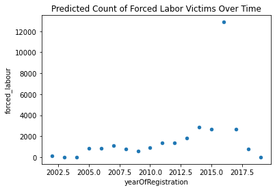

```python
# Scatter plot of the count of observed and predicted victims of forced labor over time
exploit_year_predicted.reset_index(inplace=True)
exploit_year_predicted.plot.scatter(x='yearOfRegistration', y='forced_labour', title='Predicted Count of Forced Labor Victims Over Time')
```

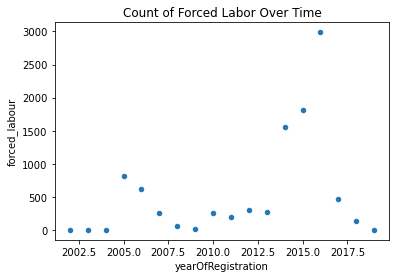

```python
# Original scatter plot with no predicted values
exploit_year_df.plot.scatter(x='yearOfRegistration', y='forced_labour', title='Count of Forced Labor Over Time')
```

Comparing the predicted and original scatter plots, the predicted plot accounts for over 12,000 victims of forced labor around 2016 alone while the original plot only went up to slightly above 3,000 in 2016. The model predicted that around 9,000 of the individuals with missing data were victims of forced labor. This is a dramatic difference in number and is the observed data was only looked at and no effort was made to predict the number of victims, than someone viewing the data could be mislead to believe that there were not as many cases of forced labor trafficking over time. This could lead to all sorts of assumptions, such as the assumption that forced labor trafficking is not as grave of an issue and downplaying it instead.

### Sex Exploit

```python
# Dropping rows with NaN in isSexualExploit column for the machine learning algorithm to impute on
df_sex = data_table.dropna(subset=['isSexualExploit'], how='all')
```

```python
# Creating the pipeline of imputation to random forest modelling of the dataset
# 10-fold cross-validation is applied to this pipeline to reduce the bias of the evaulation of the model/pipeline

df_values = df_sex.values
# X_sex represents the input feature (all other features besides isSexualExploit)
# y_sex represents the output feature (isSexualExploit)
index = [i for i in range(table.shape[1]) if i != 27]
X_sex, y_sex = df_values[:, index], df_values[:, 27]
model = RandomForestClassifier(n_estimators=50, max_depth=5)
imputer = IterativeImputer()
pipeline = Pipeline(steps=[('i', imputer), ('m', model)])
# Define model evaluation
cv = RepeatedStratifiedKFold(n_splits=10, n_repeats=3, random_state=1)
# Evaluate model
scores = cross_val_score(pipeline, X_sex.tolist(), y_sex.tolist(), scoring='accuracy', cv=cv, n_jobs=-1, error_score='raise')
# Print the mean accuracy of the model based on the scores received from the cross-validation
print('Mean Accuracy: %.3f (%.3f)' % (np.mean(scores), np.std(scores)))
```

```
Mean Accuracy: 0.989 (0.002)
```

```python
# The missing rows of the column are dropped with drop and placed in a separate dataframe
df_sex_na = pd.DataFrame.copy(data_table, deep=True)
df_sex_na['isSexualExploit_bool'] = df_sex_na['isSexualExploit'].isna()
df_filtered = df_sex_na[df_sex_na['isSexualExploit_bool'] == True]
df_filtered.drop(columns=['isSexualExploit_bool', 'isSexualExploit'], inplace=True)
```

```python
# Fit the model
pipeline.fit(X_sex.tolist(), y_sex.tolist())
# Make the predictions
sex_prediction = pipeline.predict(df_filtered)
```

```python
# non-nan columns
df_sex_predicted = pd.DataFrame.copy(data, deep=True)
df_sex_predicted.dropna(subset=['isSexualExploit'], how='all', inplace=True)

# nan colums
data_half = pd.DataFrame.copy(data, deep=True)
data_half['isSexualExploit_bool'] = df_sex_na['isSexualExploit'].isna()
df_half = data_half[data_half['isSexualExploit_bool'] == True]
df_half.drop(columns=['isSexualExploit_bool'], inplace=True)

# Assign predictions to missing values
df_half = df_half.assign(isSexualExploit=np.array(sex_prediction))

# Concatenate two halves of dataframe
df_sex_predicted = pd.concat([df_sex_predicted, df_half])
```

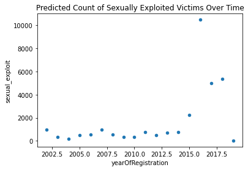

```python
# Scatter plot of predicted count of sexual exploitation over time
exploit_year_predicted = pd.DataFrame(df_sex_predicted.groupby('yearOfRegistration').agg(sexual_exploit=("isSexualExploit", np.sum)))
exploit_year_predicted.reset_index(inplace=True)
exploit_year_predicted.plot.scatter(x='yearOfRegistration', y='sexual_exploit', title='Predicted Count of Sexually Exploited Victims Over Time')
```

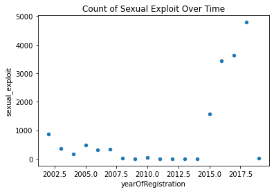

```python
# Observed
exploit_year_df.plot.scatter(x='yearOfRegistration', y='sexual_exploit', title='Count of Sexual Exploit Over Time', xlabel='Year', ylabel='Count')
```

### Other Exploit

```python
# Dropping rows with NaN in isOtherExploit column for the machine learning algorithm to impute on
df_other = data_table.dropna(subset=['isOtherExploit'], how='all')
```

```python
# Creating the pipeline of imputation to random forest modelling of the dataset
# 10-fold cross-validation is applied to this pipeline to reduce the bias of the evaulation of the model/pipeline

df_values = df_other.values
# X_other represents the input feature (all other features besides isOtherExploit)
# y_other represents the output feature (isOtherExploit)
index = [i for i in range(table.shape[1]) if i != 28]
X_other, y_other = df_values[:, index], df_values[:, 28]
model = RandomForestClassifier(n_estimators=50, max_depth=5)
imputer = IterativeImputer()
pipeline = Pipeline(steps=[('i', imputer), ('m', model)])
# define model evaluation
cv = RepeatedStratifiedKFold(n_splits=10, n_repeats=3, random_state=1)
# evaluate model
scores = cross_val_score(pipeline, X_other.tolist(), y_other.tolist(), scoring='accuracy', cv=cv, n_jobs=-1, error_score='raise')
print('Mean Accuracy: %.3f (%.3f)' % (np.mean(scores), np.std(scores)))
```

```
Mean Accuracy: 0.999 (0.001)
```

```python
# The missing rows of the column are dropped with drop and placed in a separate dataframe
df_other_na = pd.DataFrame.copy(data_table, deep=True)
df_other_na['isOtherExploit_bool'] = df_other_na['isOtherExploit'].isna()
df_filtered = df_other_na[df_other_na['isOtherExploit_bool'] == True]
df_filtered.drop(columns=['isOtherExploit_bool', 'isOtherExploit'], inplace=True)
```

```python
# fit the model
pipeline.fit(X_other.tolist(), y_other.tolist())
# make the predictions
other_prediction = pipeline.predict(df_filtered)
```

```python
# non-nan columns
df_other_predicted = pd.DataFrame.copy(data, deep=True)
df_other_predicted.dropna(subset=['isOtherExploit'], how='all', inplace=True)

# nan colums
data_half = pd.DataFrame.copy(data, deep=True)
data_half['isOtherExploit_bool'] = df_other_na['isOtherExploit'].isna()
df_half = data_half[data_half['isOtherExploit_bool'] == True]
df_half.drop(columns=['isOtherExploit_bool'], inplace=True)

# Assign predictions to missing values
df_half = df_half.assign(isOtherExploit=np.array(other_prediction))

# Concatenate two halves of dataframe
df_other_predicted = pd.concat([df_other_predicted, df_half])
```

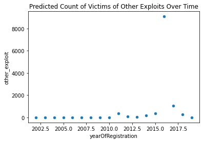

```python
# Scatter plot of predicted count of other exploit over time
exploit_year_predicted = pd.DataFrame(df_other_predicted.groupby('yearOfRegistration').agg(other_exploit=("isOtherExploit", np.sum)))
exploit_year_predicted.reset_index(inplace=True)
exploit_year_predicted.plot.scatter(x='yearOfRegistration', y='other_exploit', title='Predicted Count of Victims of Other Exploits Over Time')
```

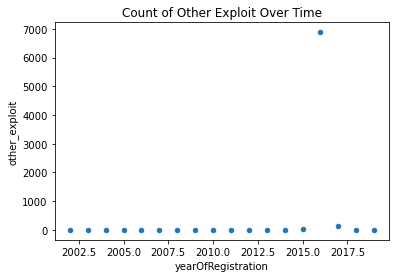

```python
# Observed
exploit_year_df.plot.scatter(x='yearOfRegistration', y='other_exploit', title='Count of Other Exploit Over Time', xlabel='Year', ylabel='Count')
```

Almost a 2,000 difference is seen between the greatest number of victims over time in the observed data versus the predicted data.

### Sex and Labor

```python
# Dropping rows with NaN in isSexAndLabour column for the machine learning algorithm to impute on
df_sexlabor = data_table.dropna(subset=['isSexAndLabour'], how='all')
```

```python
# Creating the pipeline of imputation to random forest modelling of the dataset
# 10-fold cross-validation is applied to this pipeline to reduce the bias of the evaulation of the model/pipeline

df_values = df_sexlabor.values
# X_sl represents the input feature (all other features besides isSexAndLabour)
# y_sl represents the output feature (isSexAndLabour)
index = [i for i in range(table.shape[1]) if i != 29]
X_sl, y_sl = df_values[:, index], df_values[:, 29]
model = RandomForestClassifier(n_estimators=50, max_depth=5)
imputer = IterativeImputer()
pipeline = Pipeline(steps=[('i', imputer), ('m', model)])
# define model evaluation
cv = RepeatedStratifiedKFold(n_splits=10, n_repeats=3, random_state=1)
# evaluate model
scores = cross_val_score(pipeline, X_sl.tolist(), y_sl.tolist(), scoring='accuracy', cv=cv, n_jobs=-1, error_score='raise')
print('Mean Accuracy: %.3f (%.3f)' % (np.mean(scores), np.std(scores)))
```

```
Mean Accuracy: 1.000 (0.000)
```

The mean accuracy is 1 here likely due to overfitting as there are not as many cases of sex and labor exploitation victims and therefore less data for the pipeline to impute and model.

```python
# The missing rows of the column are dropped with drop and placed in a separate dataframe
df_sl_na = pd.DataFrame.copy(data_table, deep=True)
df_sl_na['isSexAndLabour_bool'] = df_other_na['isSexAndLabour'].isna()
df_filtered = df_sl_na[df_sl_na['isSexAndLabour_bool'] == True]
df_filtered.drop(columns=['isSexAndLabour_bool', 'isSexAndLabour'], inplace=True)
```

```python
# fit the model
pipeline.fit(X_sl.tolist(), y_sl.tolist())
# make the predictions
sl_prediction = pipeline.predict(df_filtered)
```

```python
# non-nan columns
df_sl_predicted = pd.DataFrame.copy(data, deep=True)
df_sl_predicted.dropna(subset=['isSexAndLabour'], how='all', inplace=True)

# nan colums
data_half = pd.DataFrame.copy(data, deep=True)
data_half['isSexAndLabour_bool'] = df_sl_na['isSexAndLabour'].isna()
df_half = data_half[data_half['isSexAndLabour_bool'] == True]
df_half.drop(columns=['isSexAndLabour_bool'], inplace=True)

# Assign the predicted values to the missing values
df_half = df_half.assign(isSexAndLabour=np.array(sl_prediction))

# Concatenate the two halves of the dataframe
df_sl_predicted = pd.concat([df_sl_predicted, df_half])
```

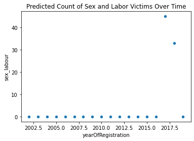

```python
# Scatter plot of predicted count of sex and labor over time
exploit_year_predicted = pd.DataFrame(df_sl_predicted.groupby('yearOfRegistration').agg(sex_labour=("isSexAndLabour", np.sum)))
exploit_year_predicted.reset_index(inplace=True)
exploit_year_predicted.plot.scatter(x='yearOfRegistration', y='sex_labour', title='Predicted Count of Sex and Labor Victims Over Time')
```

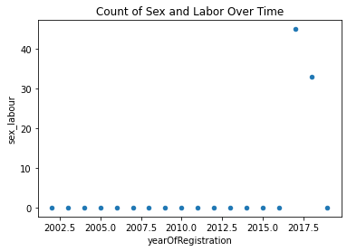

```python
# Observed
exploit_year_df.plot.scatter(x='yearOfRegistration', y='sex_labour', title='Count of Sex and Labor Over Time', xlabel='Year', ylabel='Count')
```

Unlike the other types of exploit, no big difference is seen between the two scatter plots.

### Forced Marriage, Slavery and Practices, and Abduction

The remaining three types of exploit are condensed in the following cells but the same process as before is used to predict the missing values.

```python
# Dropping rows with NaN in the feature column for the machine learning algorithm to impute on
df_marriage = data_table.dropna(subset=['isForcedMarriage'], how='all')
df_slavery = data_table.dropna(subset=['isSlaveryAndPractices'], how='all')
df_abduction = data_table.dropna(subset=['isAbduction'], how='all')
```

```python
# Creating the pipeline of imputation to random forest modelling of the dataset
# 10-fold cross-validation is applied to this pipeline to reduce the bias of the evaulation of the model/pipeline

marriage_val = df_marriage.values
slavery_val = df_slavery.values
abduction_val = df_abduction.values

# X_.. represents the input feature (all other features besides the feature being predicted)
# y_.. represents the output feature (the predicted feature)
index = [i for i in range(table.shape[1]) if i != 30]
X_mar, y_mar = marriage_val[:, index], marriage_val[:, 30]

index = [i for i in range(table.shape[1]) if i != 33]
X_slavery, y_slavery = slavery_val[:, index], slavery_val[:, 33]

index = [i for i in range(table.shape[1]) if i != 34]
X_abd, y_abd = abduction_val[:, index], abduction_val[:, 34]

# Marriage model
model = RandomForestClassifier(n_estimators=50, max_depth=5)
imputer = IterativeImputer()
pipeline = Pipeline(steps=[('i', imputer), ('m', model)])
# define model evaluation
cv = RepeatedStratifiedKFold(n_splits=10, n_repeats=3, random_state=1)
# evaluate model
scores = cross_val_score(pipeline, X_mar.tolist(), y_mar.tolist(), scoring='accuracy', cv=cv, n_jobs=-1, error_score='raise')
print('Marriage Model Mean Accuracy: %.3f (%.3f)' % (np.mean(scores), np.std(scores)))

# Slavery and Practices model
# evaluate model
scores = cross_val_score(pipeline, X_slavery.tolist(), y_slavery.tolist(), scoring='accuracy', cv=cv, n_jobs=-1, error_score='raise')
print('Slavery and Practices Model Mean Accuracy: %.3f (%.3f)' % (np.mean(scores), np.std(scores)))

# Abduction model
# evaluate model
scores = cross_val_score(pipeline, X_abd.tolist(), y_abd.tolist(), scoring='accuracy', cv=cv, n_jobs=-1, error_score='raise')
print('Abduction Model Mean Accuracy: %.3f (%.3f)' % (np.mean(scores), np.std(scores)))
```

```
Marriage Model Mean Accuracy: 0.999 (0.001)
Slavery and Practices Model Mean Accuracy: 1.000 (0.000)
Abduction Model Mean Accuracy: 0.998 (0.000)
```

The mean accuracy for the slavery and practices model also is 1 here likely due to overfitting as there are not as many cases of slavery and practices exploitation victims and therefore less data for the pipeline to impute and model. The other mean accuracies are also very close to 1 likely for similar reasons of overfitting due to a lack in the amount of victims of those types of exploitation in the dataset.

```python
# The missing rows of the column are dropped with drop and placed in a separate dataframe

df_mar_na = pd.DataFrame.copy(data_table, deep=True)
df_mar_na['isForcedMarriage_bool'] = df_mar_na['isForcedMarriage'].isna()
df_filtered_mar = df_mar_na[df_mar_na['isForcedMarriage_bool'] == True]
df_filtered_mar.drop(columns=['isForcedMarriage_bool', 'isForcedMarriage'], inplace=True)

df_slavery_na = pd.DataFrame.copy(data_table, deep=True)
df_slavery_na['isSlaveryAndPractices_bool'] = df_slavery_na['isSlaveryAndPractices'].isna()
df_filtered_sl = df_slavery_na[df_slavery_na['isSlaveryAndPractices_bool'] == True]
df_filtered_sl.drop(columns=['isSlaveryAndPractices_bool', 'isSlaveryAndPractices'], inplace=True)

df_a_na = pd.DataFrame.copy(data_table, deep=True)
df_a_na['isAbduction_bool'] = df_a_na['isAbduction'].isna()
df_filtered_a = df_a_na[df_a_na['isAbduction_bool'] == True]
df_filtered_a.drop(columns=['isAbduction_bool', 'isAbduction'], inplace=True)
```

```python
# Marriage model
# fit the model
pipeline.fit(X_mar.tolist(), y_mar.tolist())
# make a prediction
mar_prediction = pipeline.predict(df_filtered_mar)

# Slavery and practices model
# fit the model
pipeline.fit(X_slavery.tolist(), y_slavery.tolist())
# make a prediction
slavery_prediction = pipeline.predict(df_filtered_sl)

# Abduction model
# fit the model
pipeline.fit(X_abd.tolist(), y_abd.tolist())
# make a prediction
abd_prediction = pipeline.predict(df_filtered_a)
```

```python
# non-nan columns
df_mar_predicted = pd.DataFrame.copy(data, deep=True)
df_mar_predicted.dropna(subset=['isForcedMarriage'], how='all', inplace=True)

df_slavery_predicted = pd.DataFrame.copy(data, deep=True)
df_slavery_predicted.dropna(subset=['isSlaveryAndPractices'], how='all', inplace=True)

df_abd_predicted = pd.DataFrame.copy(data, deep=True)
df_abd_predicted.dropna(subset=['isAbduction'], how='all', inplace=True)

# forced marriage
data_half = pd.DataFrame.copy(data, deep=True)
data_half['isForcedMarriage_bool'] = df_mar_na['isForcedMarriage'].isna()
df_half = data_half[data_half['isForcedMarriage_bool'] == True]
df_half.drop(columns=['isForcedMarriage_bool'], inplace=True)

df_half = df_half.assign(isForcedMarriage=np.array(mar_prediction))
df_mar_predicted = pd.concat([df_mar_predicted, df_half])

# slavery and practices
data_half = pd.DataFrame.copy(data, deep=True)
data_half['isSlaveryAndPractices_bool'] = df_slavery_na['isSlaveryAndPractices'].isna()
df_half = data_half[data_half['isSlaveryAndPractices_bool'] == True]
df_half.drop(columns=['isSlaveryAndPractices_bool'], inplace=True)

df_half = df_half.assign(isSlaveryAndPractices=np.array(slavery_prediction))
df_slavery_predicted = pd.concat([df_slavery_predicted, df_half])

# abduction
data_half = pd.DataFrame.copy(data, deep=True)
data_half['isAbduction_bool'] = df_a_na['isAbduction'].isna()
df_half = data_half[data_half['isAbduction_bool'] == True]
df_half.drop(columns=['isAbduction_bool'], inplace=True)

df_half = df_half.assign(isAbduction=np.array(abd_prediction))
df_a_predicted = pd.concat([df_abd_predicted, df_half])
```

#### Forced Marriage

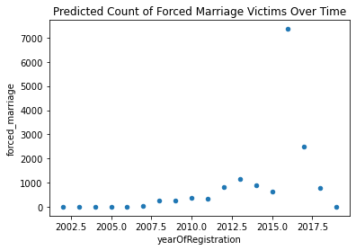

```python
# Scatter plot of predicted count of forced marriage over time
mar_year_predicted = pd.DataFrame(df_mar_predicted.groupby('yearOfRegistration').agg(forced_marriage=("isForcedMarriage", np.sum)))
mar_year_predicted.reset_index(inplace=True)
mar_year_predicted.plot.scatter(x='yearOfRegistration', y='forced_marriage', title='Predicted Count of Forced Marriage Victims Over Time')
```

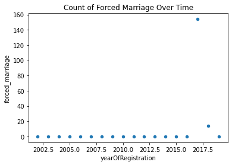

```python
# Observed
exploit_year_df.plot.scatter(x='yearOfRegistration', y='forced_marriage', title='Count of Forced Marriage Over Time', xlabel='Year', ylabel='Count')
```

There is almost a 7,000 difference between the observed peak around late or early 2016-2017 and the predicted count fot that time.

#### Slavery and Practices

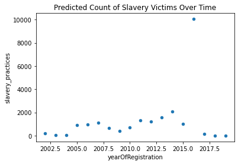

```python
# Scatter plot of predicted count of slavery and practices over time
slavery_year_predicted = pd.DataFrame(df_slavery_predicted.groupby('yearOfRegistration').agg(slavery_practices=("isSlaveryAndPractices", np.sum)))
slavery_year_predicted.reset_index(inplace=True)
slavery_year_predicted.plot.scatter(x='yearOfRegistration', y='slavery_practices', title='Predicted Count of Slavery Victims Over Time')
```

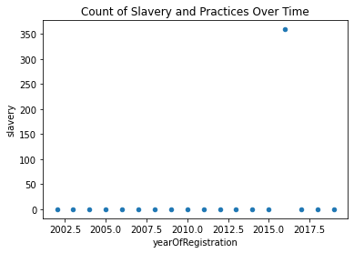

```python
# Observed
exploit_year_df.plot.scatter(x='yearOfRegistration', y='slavery', title='Count of Slavery and Practices Over Time', xlabel='Year', ylabel='Count')
```

#### Abduction

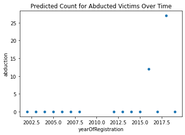

```python
# Scatter plot of predicted count of abduction over time
abduction_year_predicted = pd.DataFrame(df_abd_predicted.groupby('yearOfRegistration').agg(abduction=("isAbduction", np.sum)))
abduction_year_predicted.reset_index(inplace=True)
abduction_year_predicted.plot.scatter(x='yearOfRegistration', y='abduction', title='Predicted Count for Abducted Victims Over Time')
```

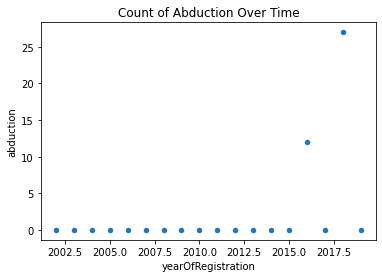

```python
# Observed
exploit_year_df.plot.scatter(x='yearOfRegistration', y='abduction', title='Count of Abduction Over Time', xlabel='Year', ylabel='Count')
```

# Conclusion

## Concluding Thoughts

Reliable and non-missing human trafficking data can be difficult to obtain and therefore perform analysis on. Despite these challenges often seen in the real world, this tutorial walked through the stages of the data science pipeline in analyzing possible relationships that occur in existing data and attempting to predict missing values to use in further anaysis.

The data was first gathered and read into a dataframe as part of the data collection and management step. Missing values were accounted for and the dataframe was ready for manipulation and anlysis. Then, the data was explored to visualize the patterns and trends in the data. I analyzed some of the main features of the dataset including age, gender, and type of exploitation. Sexual exploitation was the most common type of exploitation observed in the dataset and the United States was the most frequent country exploitation took place. This step allowed us to fiddle with the data and inform what should be done in the next step: machine learning. The exploratory data analysis lead to an interest in what missing values would be classified as based on the existing data and how those classifications would or would not change the distribution of the data. Therefore, a pipeline of imputation and random forest classification was implemented to predict what missing values in respect to the types of exploitation would be.

## Further Application

This tutorial can be extended futher to attempt to predict other missing features in the dataset. One of these features could be the country of exploitation and the country of citizenship. If machine learning algorithms are employed on the relationships between the countries, then it could be possible to predict the routes in which perpetrators transport or send trafficked victims and the different clusters that may exist.

In the end, analyzing human trafficking data should help in rescuing and helping trafficked victims and trying to break the cycle of trafficking by catching perpetrators in the middle.

## Additional Resources on Human Trafficking

For more information regarding human trafficking, refer to the National Human Trafficking Hotline: https://humantraffickinghotline.org/

If you or someone you know is a victim of humam trafficking, you can call 1-888-373-7888 to talk with someone and/or report a tip.